# simon-5501-07-slides

2026-10-06

## Topics to be covered

- What you will learn
  - Categorical independent variables
  - R code for categorical independent variables
  - Multiple linear regression
  - R code for multiple linear regression
  - Diagnostic plots and multicollinearity
  - R code for diagnostic plots and multicollinearity
  - Your homework

## Categorical independent variables, 1

- Regression equation
  - $Y_i=\beta_0+\beta_1 X_i+\epsilon_i$
- How do you modify this if $X_i$ is categorical?
  - Indicator variables
- Examples
  - Treatment: active drug=1, placebo=0
  - Second hand smoke: exposed=1, not exposed=0
  - Gender: male=1, female=0
- To be discussed later: three of more category levels

## Categorical independent variables, 2

- If $X_i$ = 0
  - $Y_i=\beta_0 + \beta_1 (0) + \epsilon_i$
  - $Y_i=\beta_0 + \epsilon_i$
- If $X_i$ = 1
  - $Y_i=\beta_0 + \beta_1 (1) + \epsilon_i$
  - $Y_i=\beta_0 + \beta_1 + \epsilon_i$

## Categorical independent variables, 3

- Intperetation
  - $b_0$ is the estimated average value of Y when X equals the “zero category”
  - $b_1$ is the estimated average change in Y when X changes from the “zero category” to the “one category.”

## Descriptive statistics

```r
pulmonary |>
  group_by(sex) |>
  summarize(
    fev_mean=mean(fev),
    fev_std=sd(fev) )
```

```
# A tibble: 2 × 3
  sex   fev_mean fev_std
  <chr>    <dbl>   <dbl>
1 F         2.45   0.646
2 M         2.81   1.00
```

## Creating an indicator variable

```
    fev sex sex_male
1 1.708   F        0
2 1.724   F        0
3 1.720   F        0
4 1.558   M        1
5 1.895   M        1
6 2.336   F        0
```

## Graphical display using the indicator variable

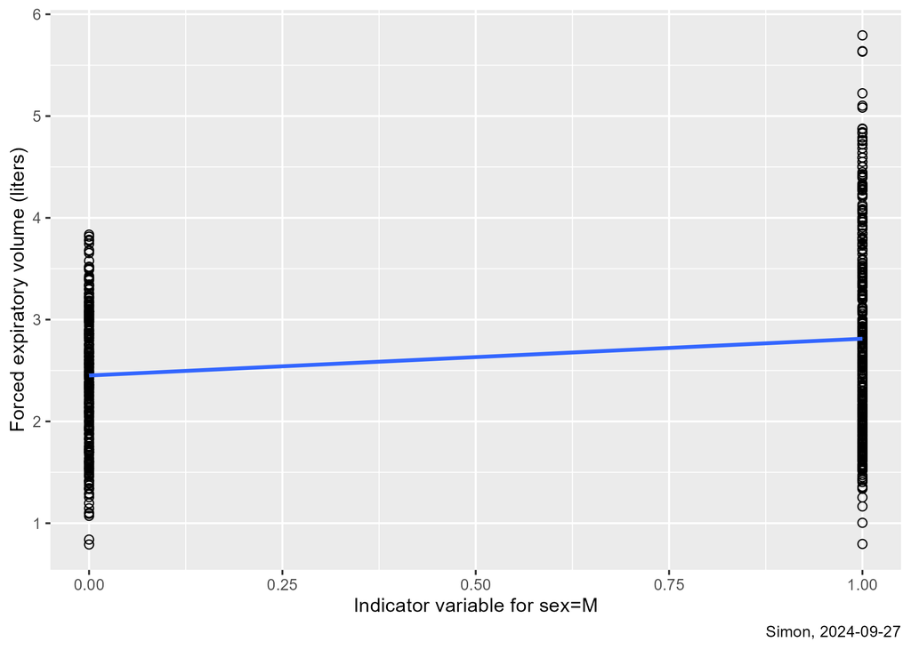

## Linear regression using the indicator variable

```r
m1 <- lm(fev ~ sex_male, data=pulmonary1)
m1
```

```
Call:
lm(formula = fev ~ sex_male, data = pulmonary1)

Coefficients:
(Intercept)     sex_male
     2.4512       0.3613
```

## Creating an alternate indicator variable

```
    fev sex sex_female
1 1.708   F          1
2 1.724   F          1
3 1.720   F          1
4 1.558   M          0
5 1.895   M          0
6 2.336   F          1
```

## Graphical display using alternate indicator variable

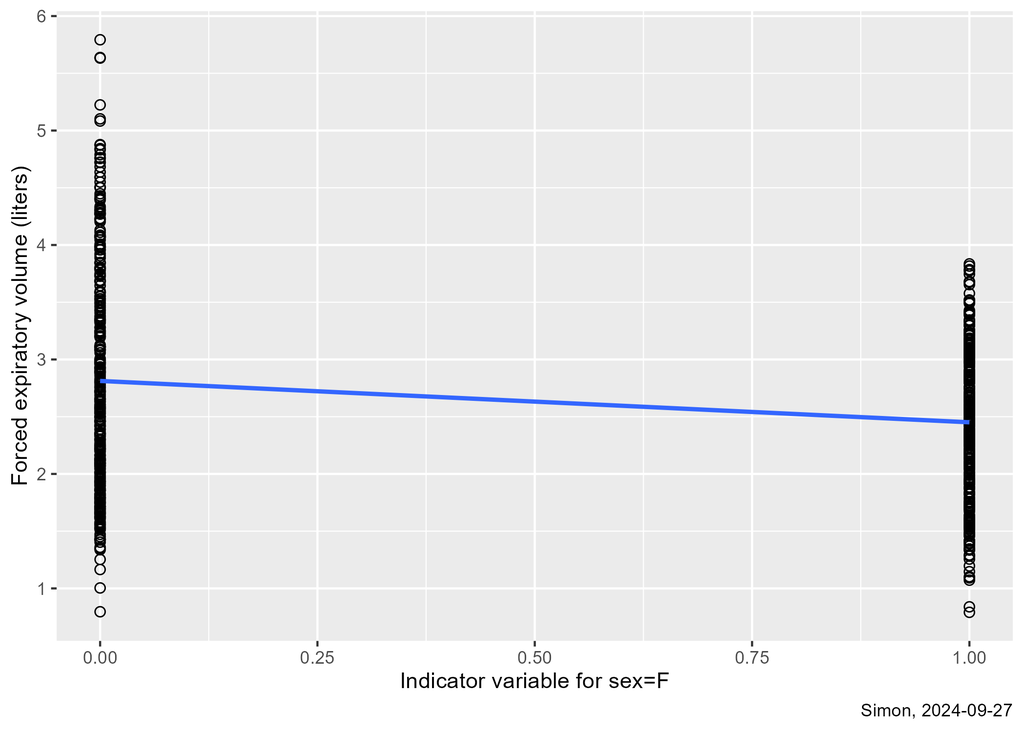

## Linear regression using alternate indicator variable

```r
m2 <- lm(fev ~ sex_female, data=pulmonary2)
m2
```

```
Call:
lm(formula = fev ~ sex_female, data = pulmonary2)

Coefficients:
(Intercept)   sex_female
     2.8124      -0.3613
```

## Letting your software create the indicator variable

- Different rules for different software
  - SPSS, SAS: first alphabetical category=1, second=0
  - R: second alphabetical category=1, first=0
- Always compare your output to the descriptive statistics

## Linear regression using alternate indicator variable

```r
m3 <- lm(fev ~ sex, data=pulmonary)
m3
```

```
Call:
lm(formula = fev ~ sex, data = pulmonary)

Coefficients:
(Intercept)         sexM
     2.4512       0.3613
```

## Break #1

- What you have learned
  - Categorical independent variables
- What’s coming next
  - R code for categorical independent variables

## Live demo, part 1

Use the following files

- Code: simon-5501-07-demo.qmd
- Data: fev.csv
- Dictionary: fev.yaml

## Break #2

- What you have learned
  - R code for categorical independent variables
- What’s coming next
  - Multiple linear regression

## Model

- $Y_i=\beta_0+\beta_1 X_{1i}+\beta_2 X_{2i}+\epsilon_i,\ i=1,...,N$
- Least squares estimates: $b_0,\ b_1,\ b_2$

## Interpretations

- $b_0$ is the estimated average value of Y when X1 and X2 both equal zero.
- $b_1$ is the estimated average change in Y
  - when $X_1$ increases by one unit, and
  - $X_2$ is held constant
- $b_2$ is the estimated average change in Y
  - when $X_2$ increases by one unit, and
  - $X_1$ is held constant

## Relationship between height and FEV unadjusted for age

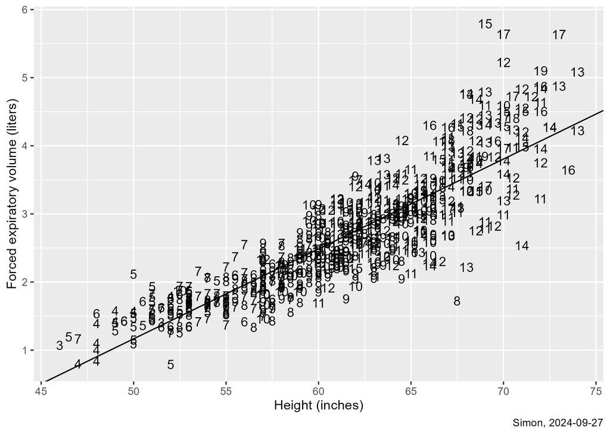

## Relationship between height and FEV controlling for age

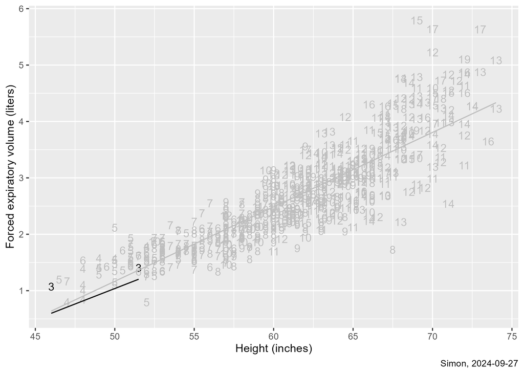

## Relationship between height and FEV controlling for age

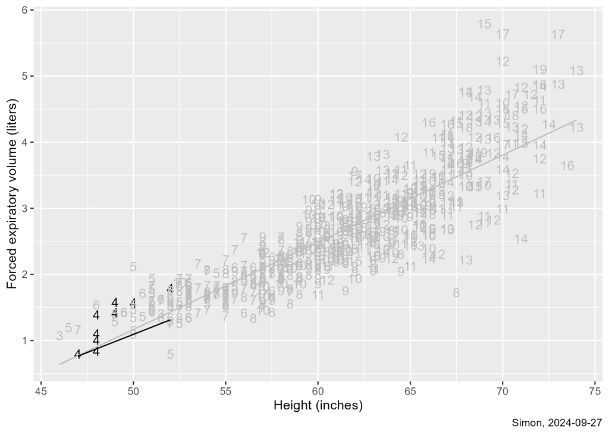

## Relationship between height and FEV controlling for age

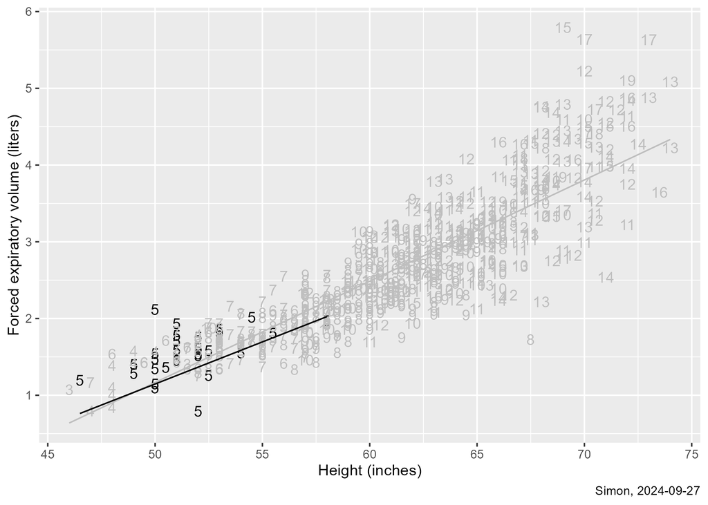

## Relationship between height and FEV controlling for age

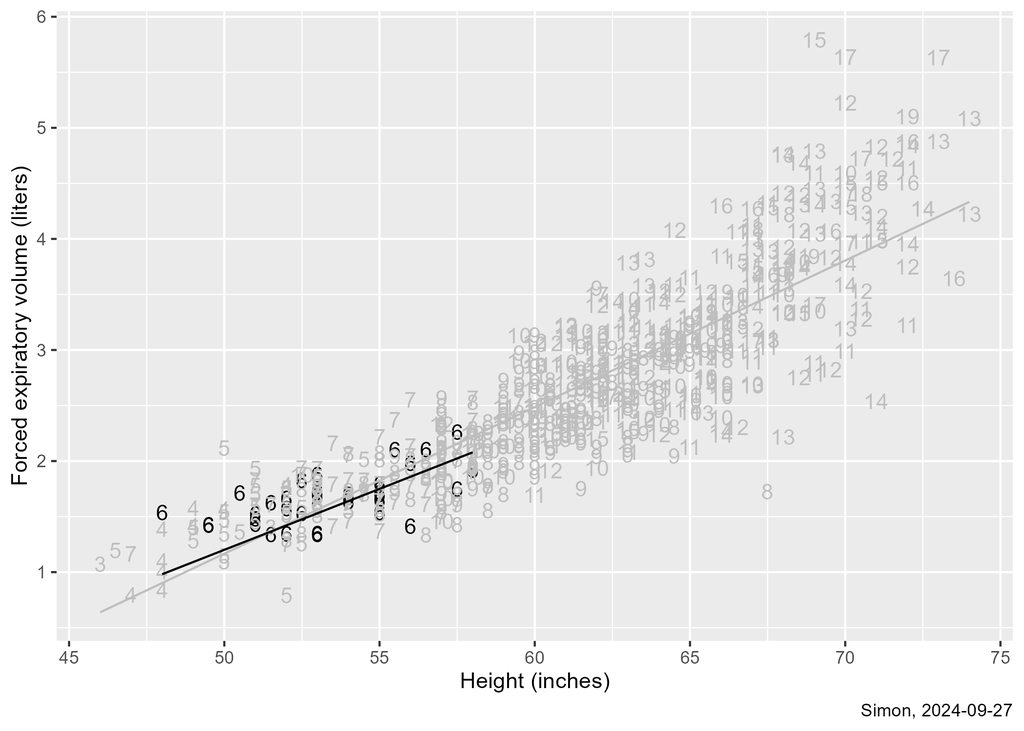

## Relationship between height and FEV controlling for age

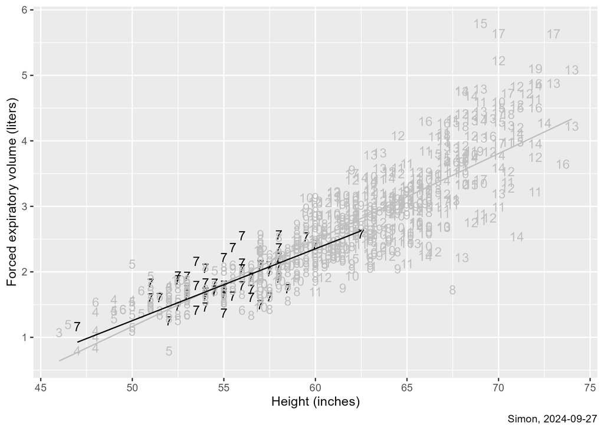

## Relationship between height and FEV controlling for age

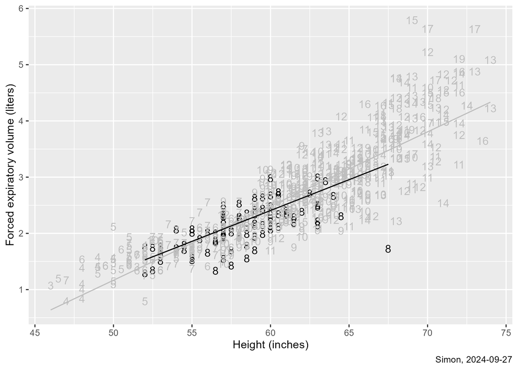

## Relationship between height and FEV controlling for age

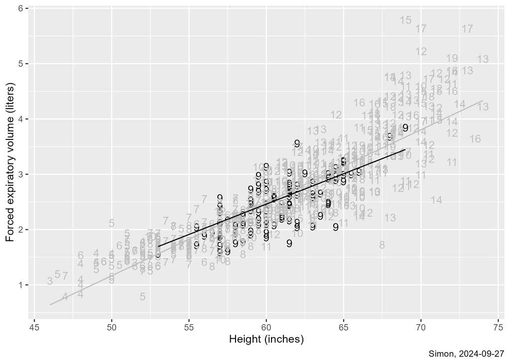

## Relationship between height and FEV controlling for age

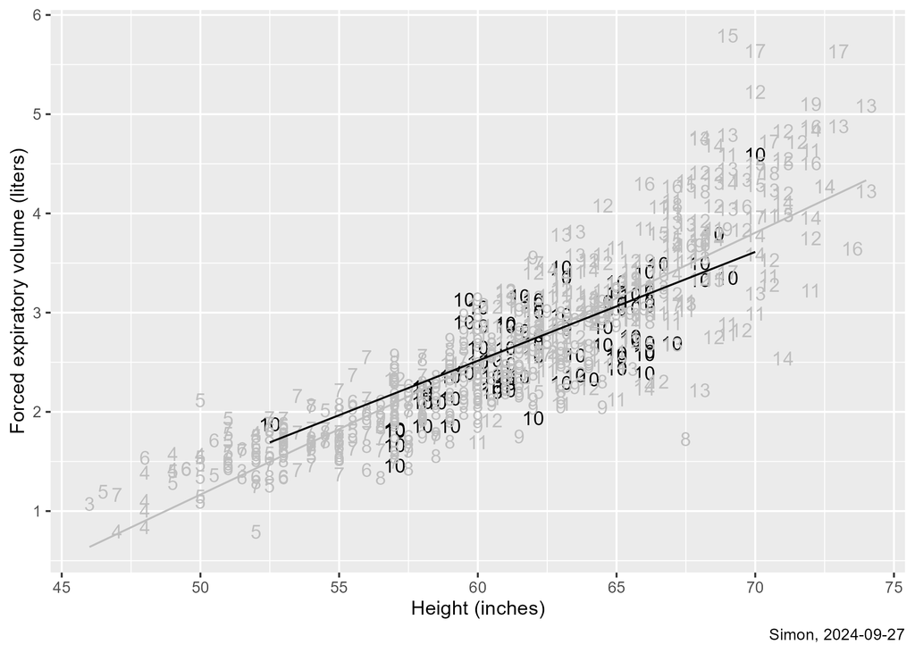

## Relationship between height and FEV controlling for age

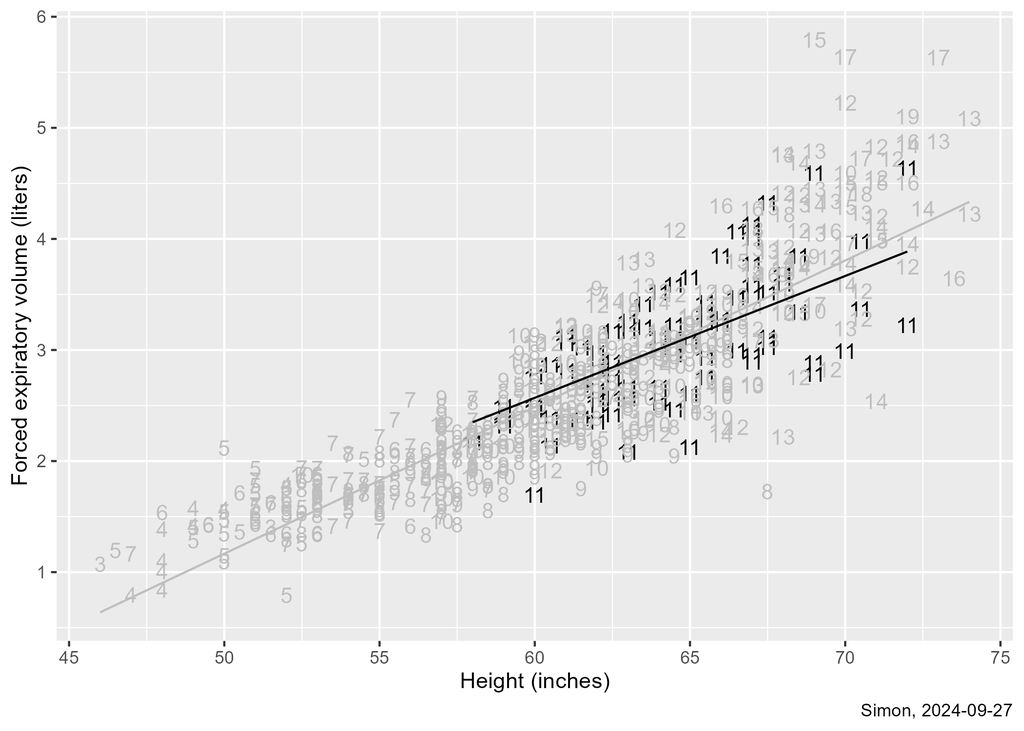

## Relationship between height and FEV controlling for age

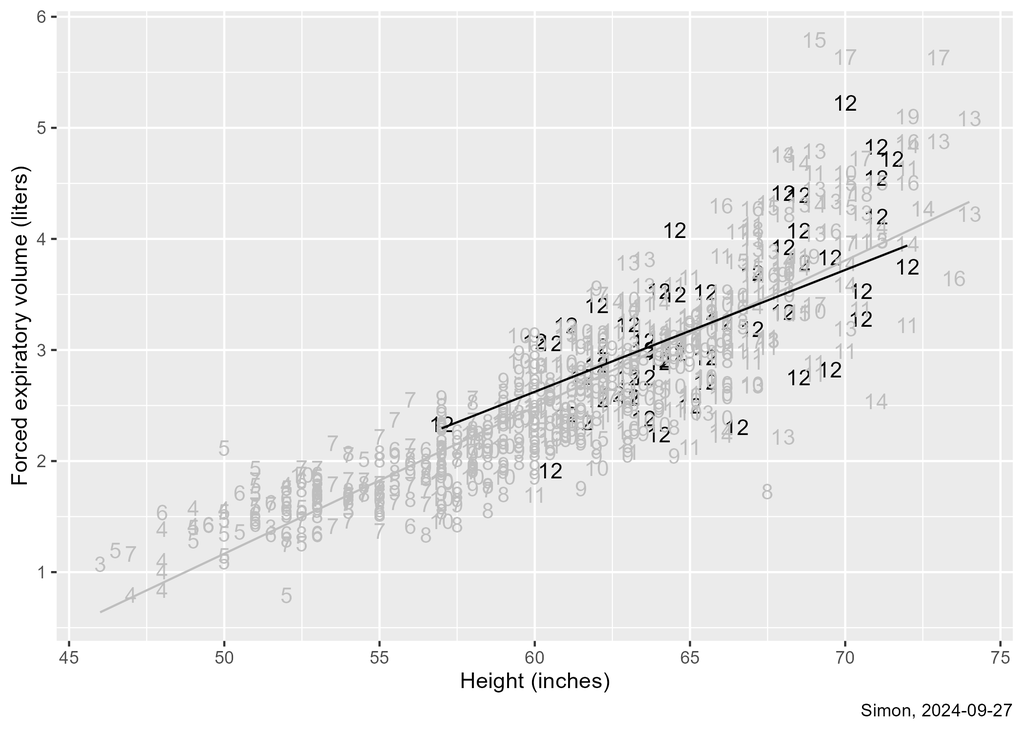

## Relationship between height and FEV controlling for age

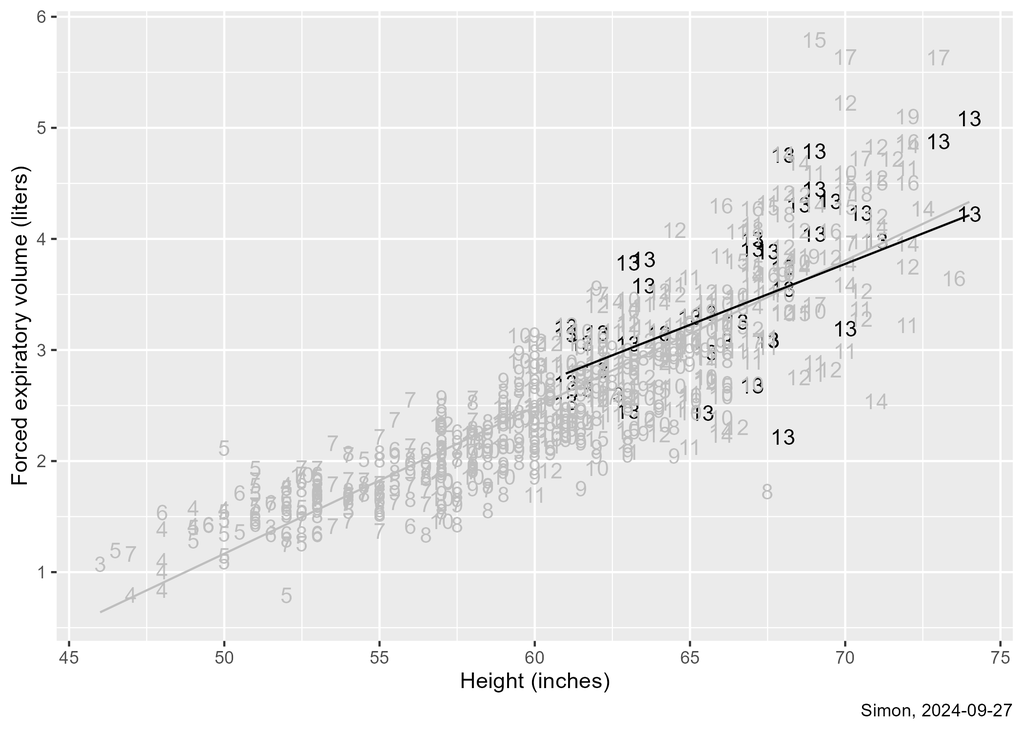

## Relationship between height and FEV controlling for age

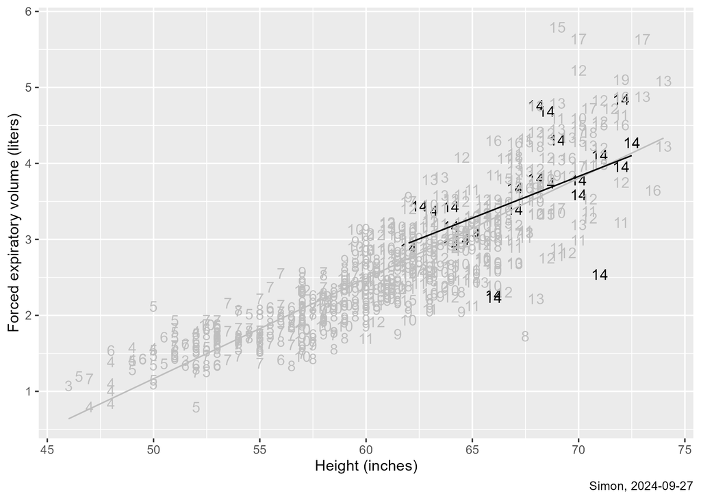

## Relationship between height and FEV controlling for age

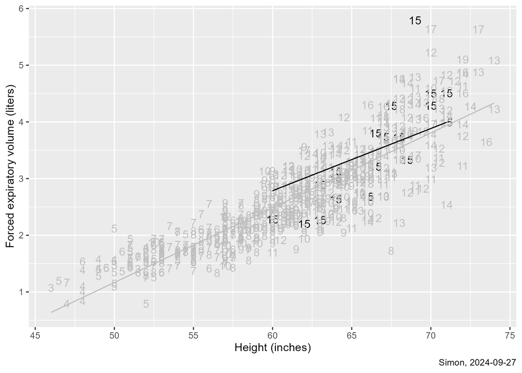

## Relationship between height and FEV controlling for age

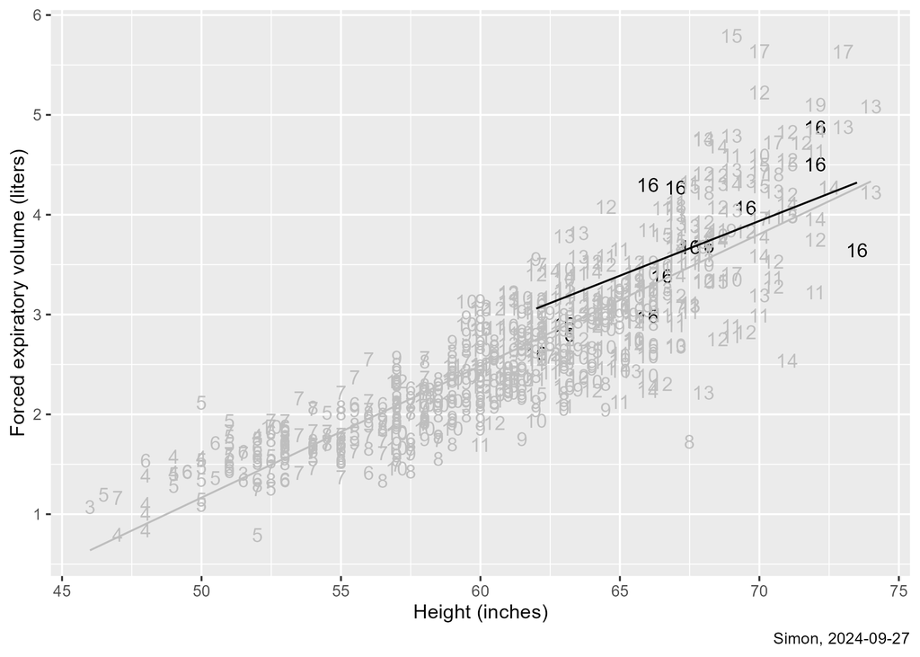

## Relationship between height and FEV controlling for age

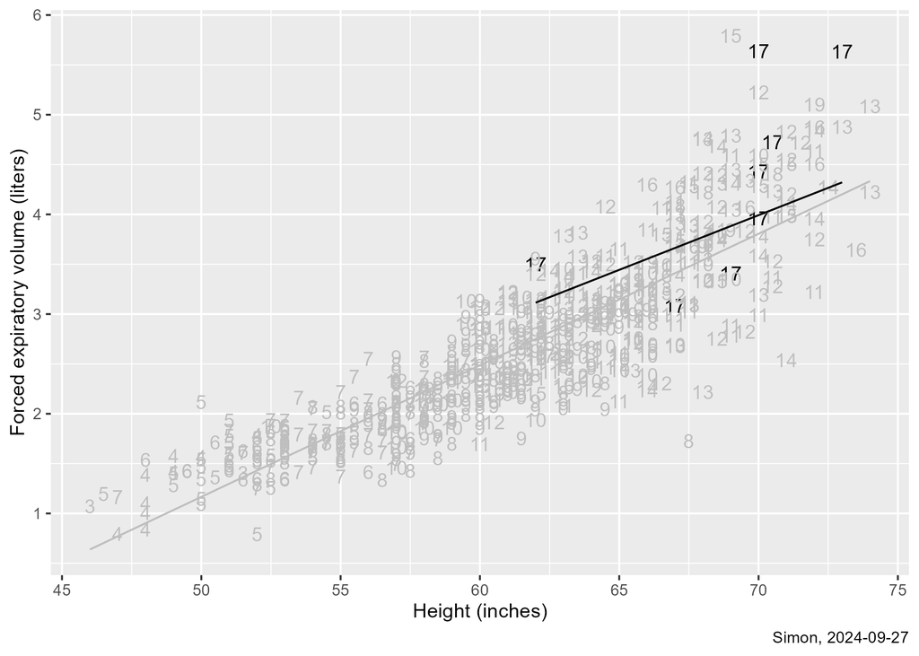

## Relationship between height and FEV controlling for age

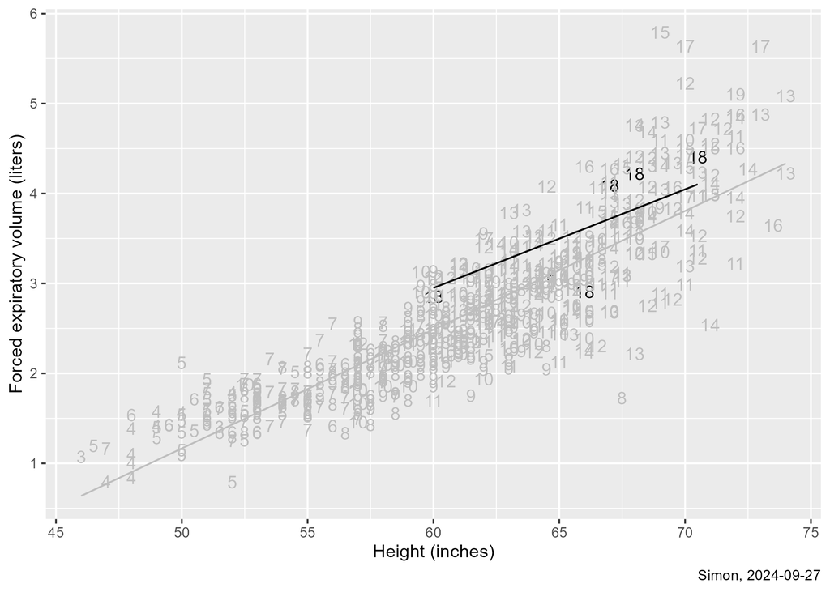

## Relationship between height and FEV controlling for age

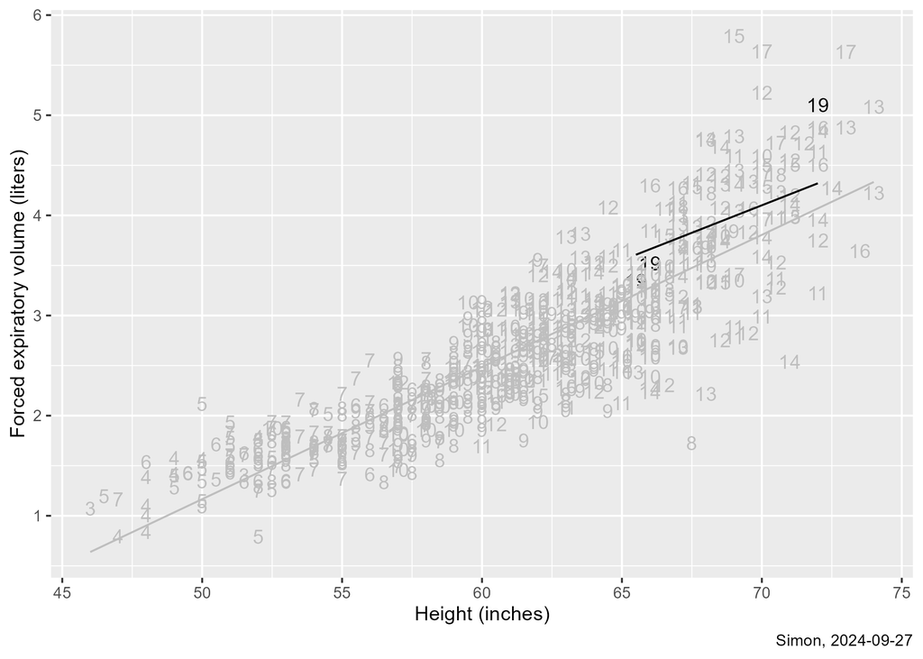

## Relationship between age and FEV unadjusted for height

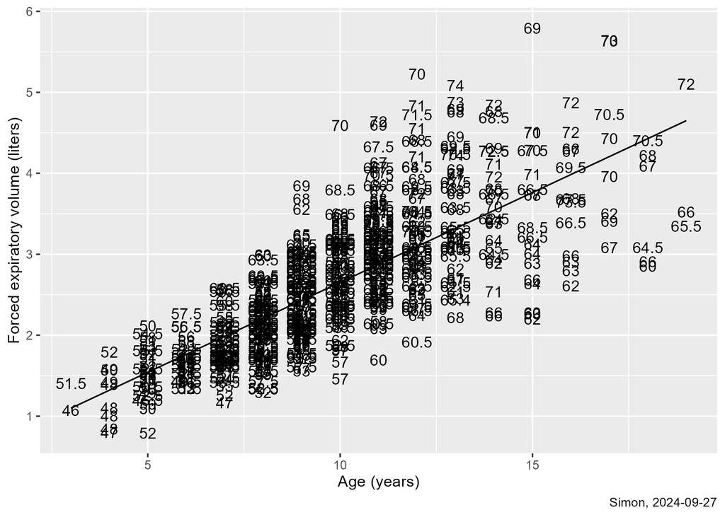

## Relationship between age and FEV controlling for height

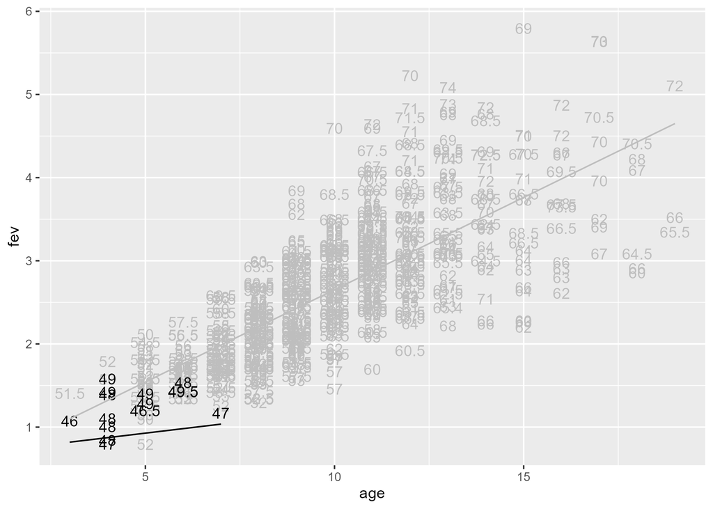

## Relationship between age and FEV controlling for height

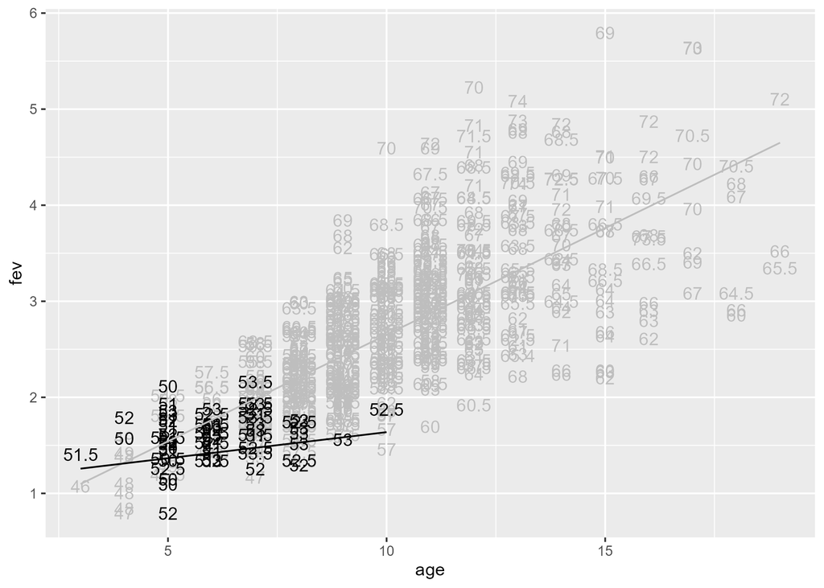

## Relationship between age and FEV controlling for height

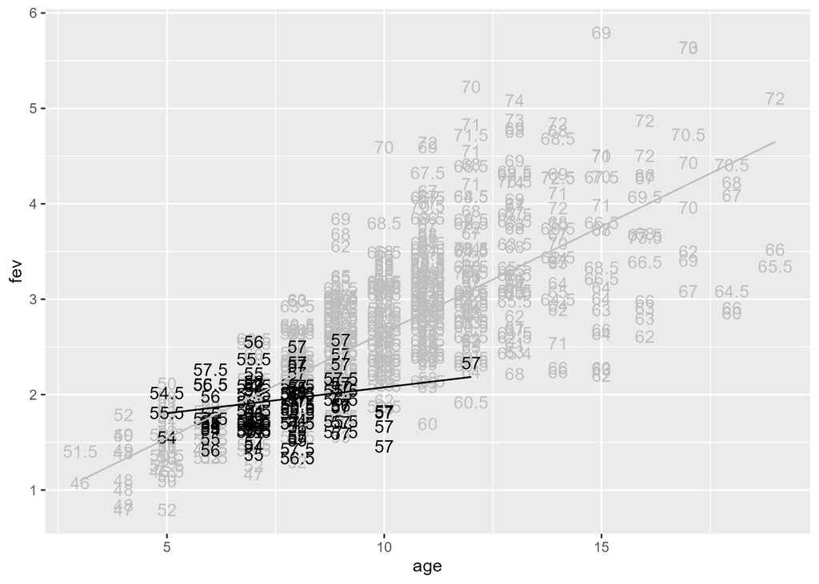

## Relationship between age and FEV controlling for height

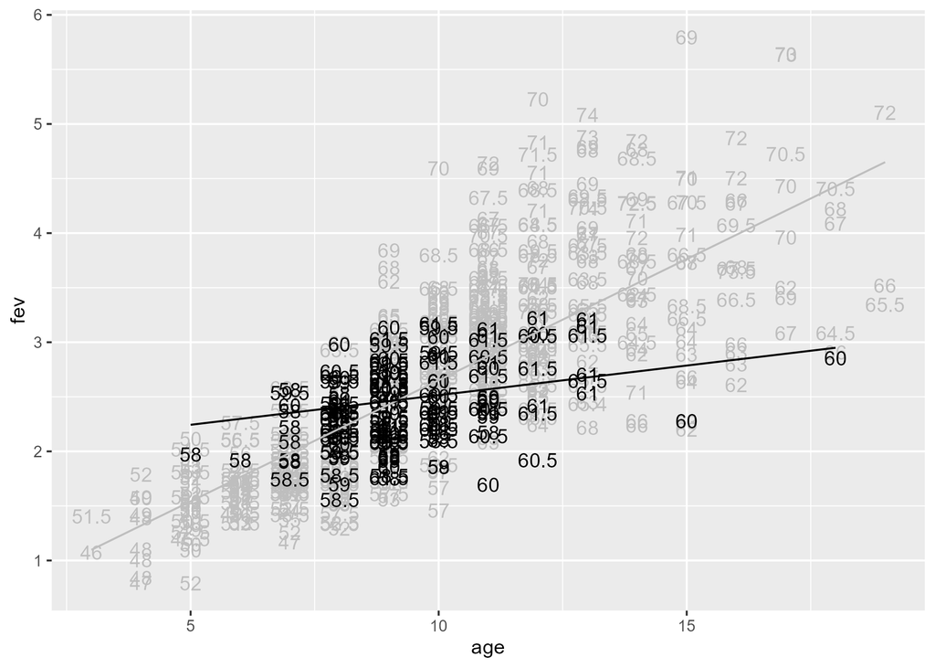

## Relationship between age and FEV controlling for height

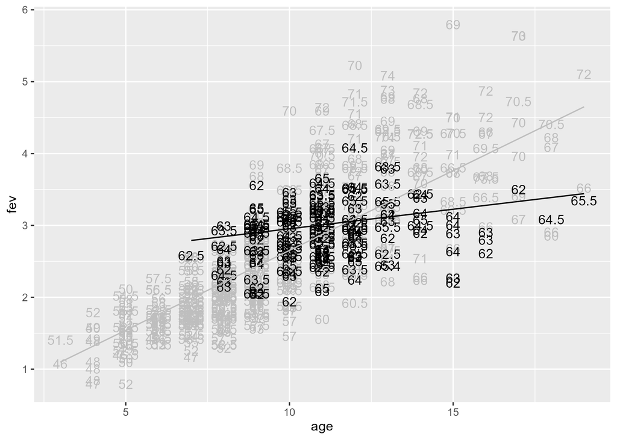

## Relationship between age and FEV controlling for height

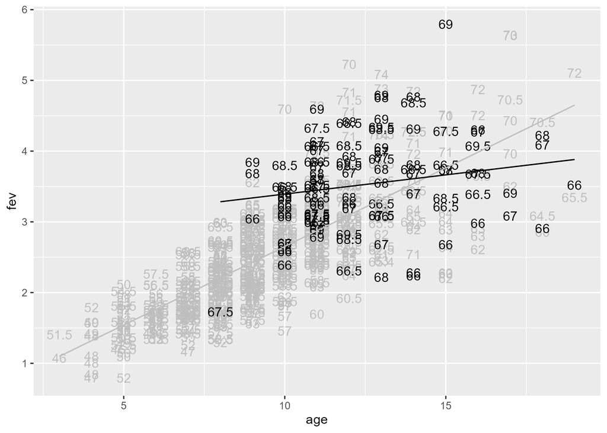

## Relationship between age and FEV controlling for height

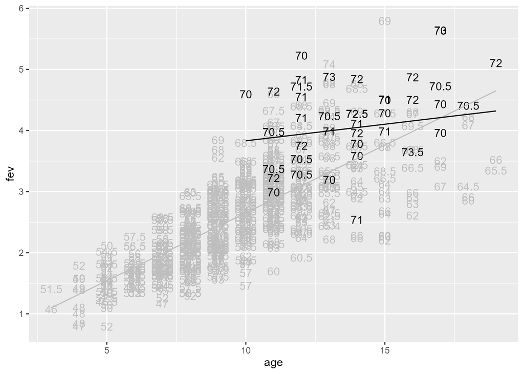

## Break #3

- What you have learned
  - Multiple linear regression
- What’s coming next
  - R code for multiple linear regression

## Live demo, part 2

Use the following files

- Code: simon-5501-07-demo.qmd
- Data: fev.csv
- Dictionary: fev.yaml

## Break #4

- What you have learned
  - R code for multiple linear regression
- What’s coming next
  - Diagnostic plots and multicollinearity

## Assumptions

- Population model
  - $Y_i=\beta_0+\beta_1 X_{1i}+\beta_2 X_{2i}+\epsilon_i,\ i=1,...,N$
- Assumptions about $\epsilon_i$
  - Normal distribution
  - Mean 0
  - Standard deviation sigma
  - Independent

## Residuals

- $\hat{Y}_i = b_0 + b_1 X_{1i} + b_2 X_{2i}$
- $e_i = Y_i - \hat{Y}_i$
  - Behavior of $e_i$ helps evaluate assumptions about $\epsilon_i$

## Assessing normality assumption

- Normal probability plot
- Histogram

## Assessing heterogeneity, nonlinearity

- Plot $e_i$ versus $\hat{Y}_i$
  - Composite of $X_1$ and $X_2$
  - Look for differences in variation
  - Look for curved pattern

## Independence is always assessed qualitatively

- Look at how your data was collected
  - Are there clusters?
    - Observations within a cluster are sometimes correlated
  - Is the outcome affected by proximity?
    - Results for infectious diseases may be correlated
- Avoid tests of independence
  - Durbin-Watson or runs tests are bad
  - More about this in Biostats-2

## Influential values

- Leverage
  - Compare to 3*(k+1)/n
    - k is number of independent variables
- Studentized deleted residual
  - Compare to $\pm 3$
- Cook’s distance
  - Compare to 1

## Leverage, 1

```
# A tibble: 15 × 9
     fev   age height .fitted  .resid   .hat .sigma  .cooksd .std.resid
   <dbl> <dbl>  <dbl>   <dbl>   <dbl>  <dbl>  <dbl>    <dbl>      <dbl>
 1  1.16     7   47     0.926  0.239  0.0148  0.420 0.00165       0.574
 2  2.91    18   66     3.61  -0.702  0.0200  0.419 0.0194       -1.69
 3  5.10    19   72     4.32   0.782  0.0171  0.419 0.0205        1.88
 4  3.52    19   66     3.66  -0.143  0.0262  0.420 0.00107      -0.345
 5  3.34    19   65.5   3.61  -0.262  0.0274  0.420 0.00376      -0.633
 6  3.08    18   64.5   3.44  -0.361  0.0231  0.420 0.00598      -0.870
 7  2.90    16   63     3.17  -0.267  0.0150  0.420 0.00208      -0.641
 8  4.22    18   68     3.83   0.393  0.0167  0.420 0.00506       0.944
 9  3.5     17   62     3.11   0.386  0.0228  0.420 0.00672       0.929
10  2.61    16   62     3.06  -0.452  0.0170  0.420 0.00679      -1.09
11  4.09    18   67     3.72   0.369  0.0183  0.420 0.00487       0.887
12  4.40    18   70.5   4.10   0.303  0.0141  0.420 0.00251       0.726
13  2.28    15   60     2.79  -0.508  0.0160  0.420 0.00810      -1.22
14  2.85    18   60     2.95  -0.0963 0.0359  0.420 0.000678     -0.234
15  2.80    16   63     3.17  -0.375  0.0150  0.420 0.00410      -0.900
```

## Leverage, 2

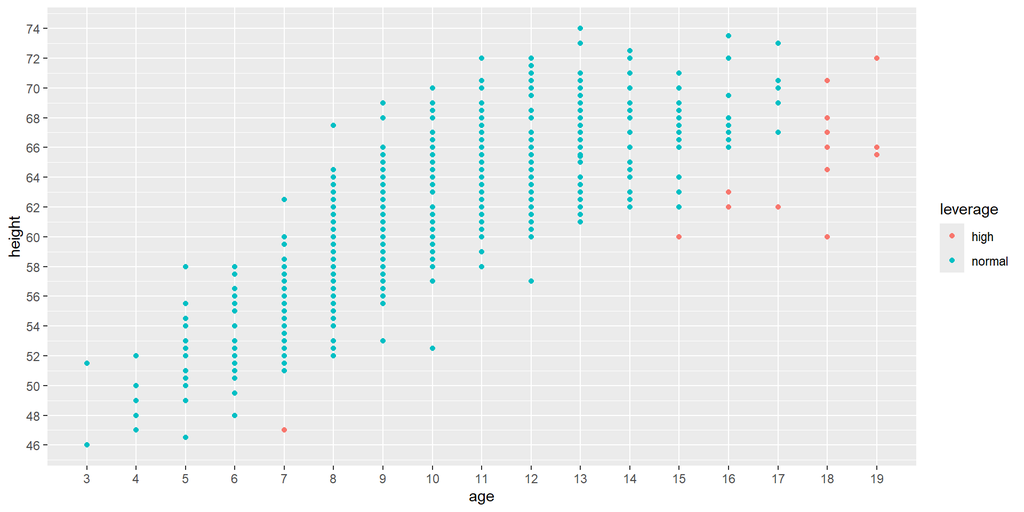

## Studentized residuals, 1

```
# A tibble: 7 × 9
    fev   age height .fitted .resid    .hat .sigma .cooksd .std.resid
  <dbl> <dbl>  <dbl>   <dbl>  <dbl>   <dbl>  <dbl>   <dbl>      <dbl>
1  1.72     8   67.5    3.23  -1.51 0.0131   0.416  0.0578      -3.61
2  5.22    12   70      3.72   1.50 0.00637  0.416  0.0276       3.59
3  2.54    14   71      3.94  -1.40 0.00610  0.416  0.0229      -3.35
4  2.22    13   68      3.56  -1.34 0.00377  0.417  0.0129      -3.20
5  5.79    15   69      3.77   2.02 0.00604  0.412  0.0472       4.83
6  5.63    17   73      4.32   1.31 0.0104   0.417  0.0347       3.14
7  5.64    17   70      3.99   1.65 0.0108   0.415  0.0565       3.94
```

## Studentized residuals, 2

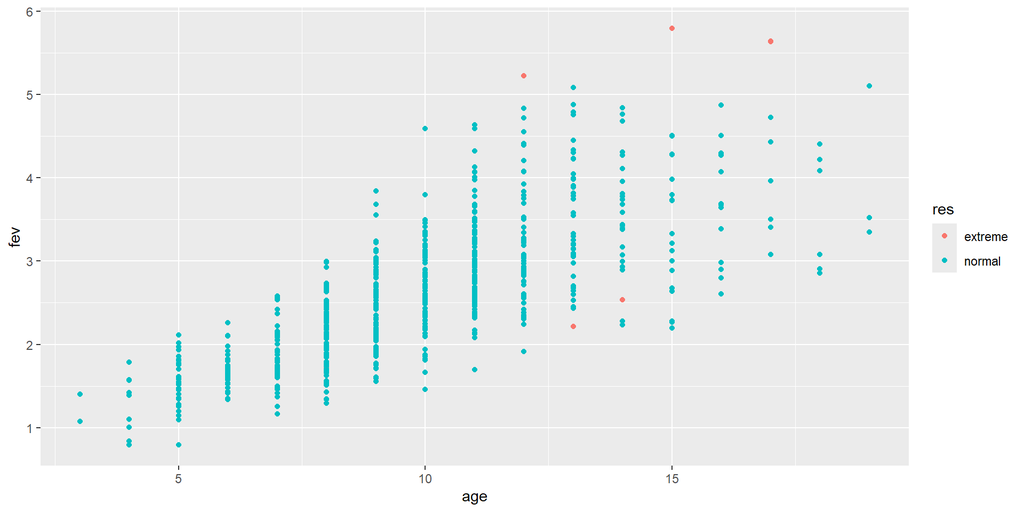

## Studentized residuals, 3

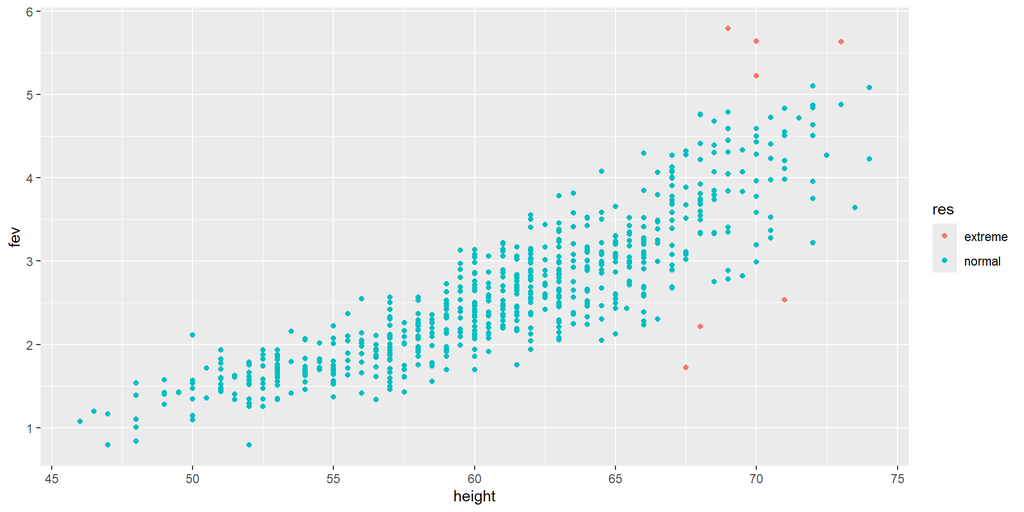

## Cook’s distance

In the pulmonary database, no combination of high leverage and extreme studentized residuals is going to cause concern.

Note: interpreting influential values gets tricky with two independent variables.

## Multicollinearity

- Synonyms:
  - Collinearity
  - Ill-conditioning
  - Near collinearity
- When two variables are correlated
- When three or more variables add up to nearly a constant

## Problems caused by multicollinearity

- Intepretation
  - What does “holding one variable constant” mean?
  - Difficult to disentangle the individual impacts
- Inflated standard errors
  - Very wide confidence intervals
  - Loss of statistical power
- Note: multicollinearity is NOT a violation of assumptions

## Variance inflation factor (VIF)

- How much precision is lost due to multicollinearity
- Values larger than 10 are cause for concern

## Break #5

- What you have learned
  - Diagnostic plots and multicollinearity
- What’s coming next
  - R code for diagnostic plots and multicollinearity

## Live demo, part 3

Use the following files

- Code: simon-5501-07-demo.qmd
- Data: fev.csv
- Dictionary: fev.yaml

## Break #6

- What you have learned
  - R code for diagnostic plots and multicollinearity
- What’s coming next
  - Your homework

## simon-5501-07-directions.qmd

Refer to the [programming assignment](https://github.com/pmean/classes/blob/master/biostats-1/07/src/simon-5501-07-directions.md) on my github site.

## Summary

- What you have learned
  - Categorical independent variables
  - R code for categorical independent variables
  - Multiple linear regression
  - R code for multiple linear regression
  - Diagnostic plots and multicollinearity
  - R code for diagnostic plots and multicollinearity
  - Your homework